# STAT 327: Project

Dawson Kinsman and Sabastian Zuhorski

2023-04-10

# Functions and Classes

Some functions and classes are imported from a separate file.

```r
source('tictactoe_functions.R')

randomSimulation = function(numSims, boardSize = 3, board = NA, df, seed = 0, colName = NA){
  set.seed(seed)

  winners<- replicate(numSims, randtictactoe(boardSize, board))
  table(winners)

  if (is.na(colName)){
    hist(winners,
       main = paste0('Results of 1,000 ',boardSize,'x', boardSize,' Tic-Tac-Toe Games'))
    df2 <- data.frame(Winner = winners,
                  'Board Size' = rep(paste0(boardSize,'x', boardSize), numSims))
  }
  else if (colName == 'First Move' | colName == 'Second Move'){
    if (colName == 'First Move'){
      df2 <- data.frame(Winner = winners, 'Move' = rep(which(board==1), numSims))}
    else{
      df2 <- data.frame(Winner = winners, 'First Move' = rep(which(board==1)),
                        'Second Move' = rep(which(board==-1), numSims))}

  }

  df <- rbind(df, df2)

  return(df)
}
```

## Constant Values

```r
n = 1e3
```

# How does the size of the board effect the probability of Player 1 winning?

First, we simulate the data using the functions we have written. We choose to run 1,000 simulations for boards with dimensions $3\times 3$, $4 \times 4$, $5 \times 5$, and $10\times 10$.

```r
df <- data.frame(matrix(ncol = 2, nrow = 0))
colnames(df) <- c('Winner', 'Board Size')

df <- randomSimulation(n, 3, df = df)
```

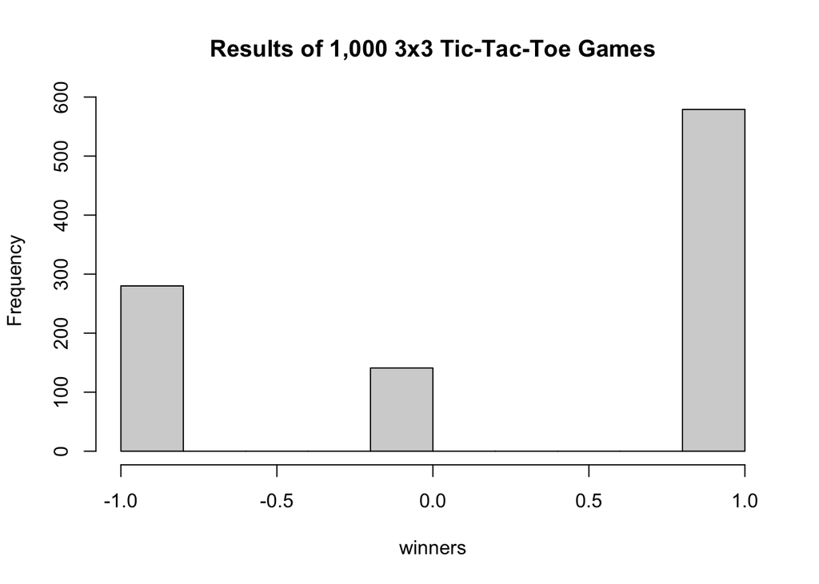

```r
df <- randomSimulation(n, 4, df = df, seed = 1)
```

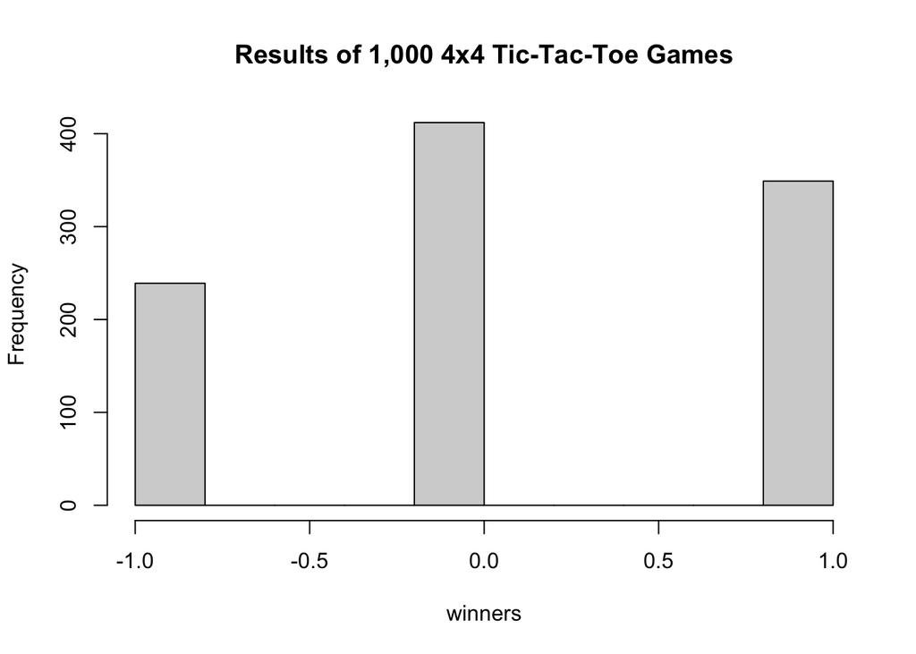

```r
df <- randomSimulation(n, 5, df = df, seed = 2)
```

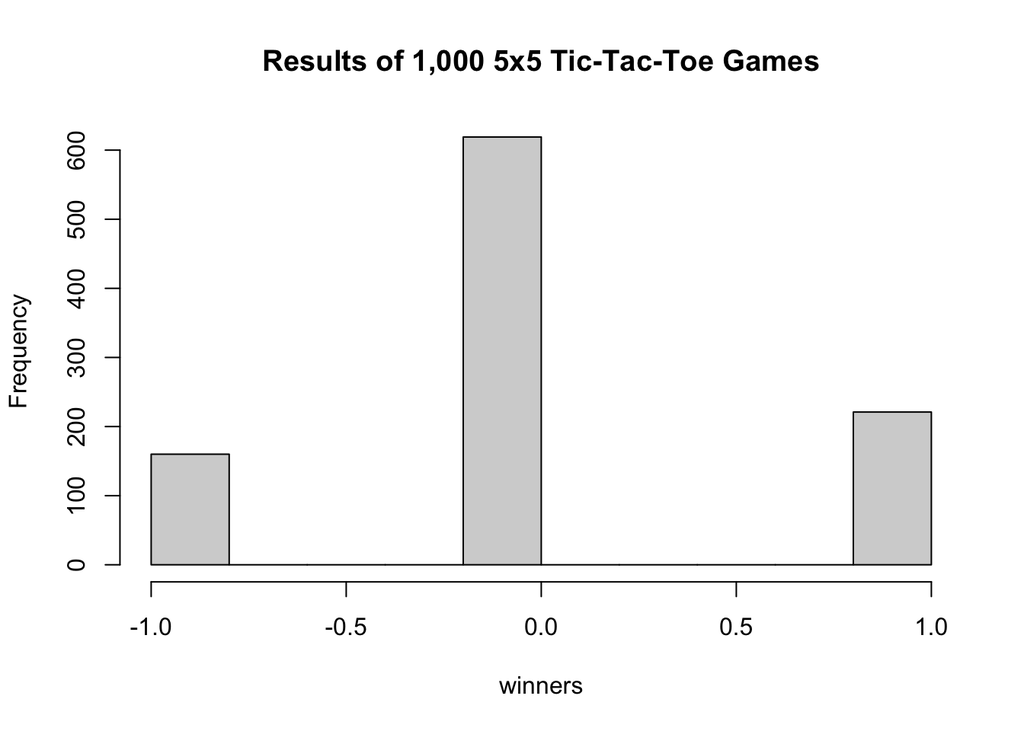

```r
df <- randomSimulation(n, 10, df = df, seed = 3)
```

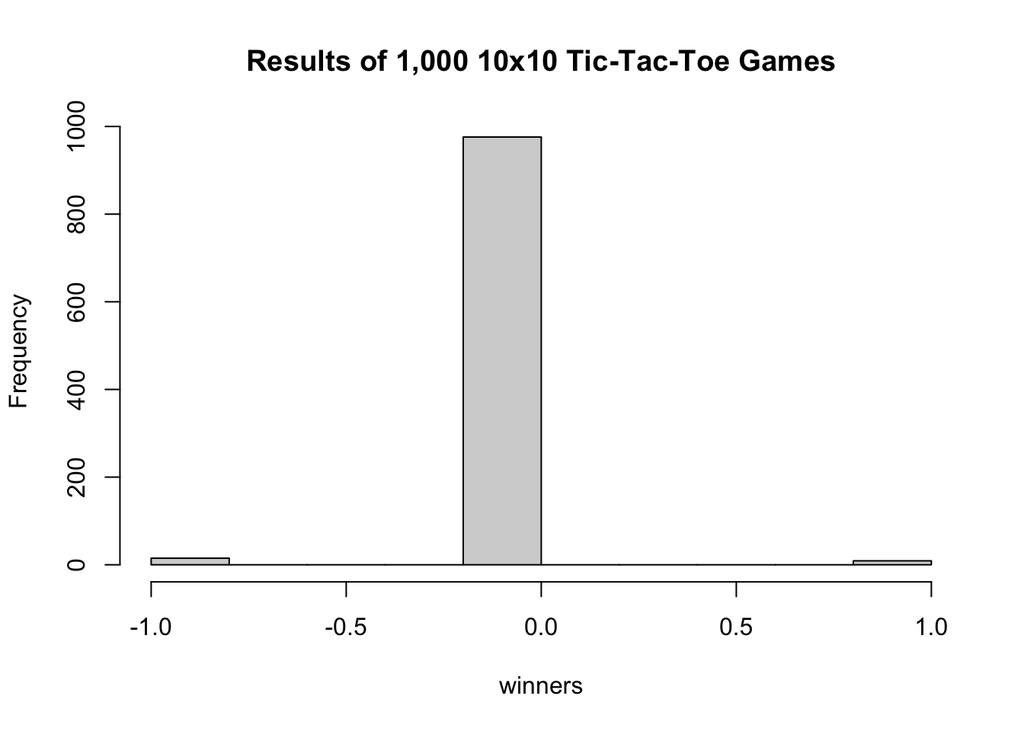

We can visualize the number of times each player wins using a bar chart.

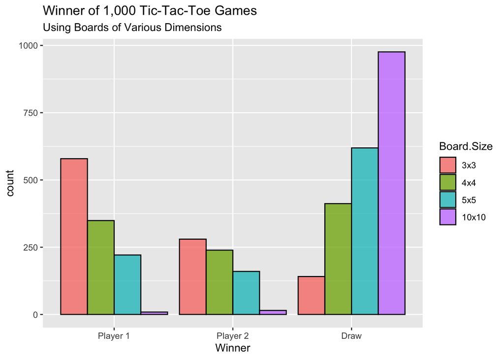

```r
boards <- c('3x3','4x4','5x5','10x10')
df$Board.Size <- factor(df$Board.Size, levels = boards)
df$Winner <- factor(df$Winner, levels = c(1, -1, 0),
                    labels = c('Player 1', 'Player 2', 'Draw'))

ggplot(df, aes(Winner)) +
  geom_bar(aes(fill = Board.Size), position = 'dodge', color = 'black',
           alpha = 0.75) +
  ggtitle('Winner of 1,000 Tic-Tac-Toe Games',
          subtitle = 'Using Boards of Various Dimensions')
```

```r
results <- data.frame(matrix(ncol = 3, nrow = 0))
colnames(results) <- c('Winner', 'Board Size', 'Probability')

for (i in boards){
  df_board <- df %>% filter(Board.Size == i)
  p1 <- length(df_board$Winner[df_board$Winner == 'Player 1']) / n; p1
  p2 <- length(df_board$Winner[df_board$Winner == 'Player 2']) / n; p2
  draw <- length(df_board$Winner[df_board$Winner == 'Draw']) / n; draw

  res <- data.frame(Winner = c('Player 1', 'Player 2', 'Draw'),
                 'Board Size' = i, Probability = c(p1,p2, draw))
  results <- rbind(results, res)
}

pt <- pivot_wider(results, id_cols = Board.Size, names_from = Winner, values_from = Probability); pt
```

```
## # A tibble: 4 × 4
##   Board.Size `Player 1` `Player 2`  Draw
##   <chr>           <dbl>      <dbl> <dbl>
## 1 3x3             0.579      0.28  0.141
## 2 4x4             0.349      0.239 0.412
## 3 5x5             0.221      0.16  0.619
## 4 10x10           0.009      0.015 0.976
```

```r
knitr::kable(pt, align = 'cccc') %>% kable_styling(full_width = F)
```

| Board.Size | Player 1 | Player 2 | Draw |
| --- | --- | --- | --- |
| 3x3 | 0.579 | 0.280 | 0.141 |
| 4x4 | 0.349 | 0.239 | 0.412 |
| 5x5 | 0.221 | 0.160 | 0.619 |
| 10x10 | 0.009 | 0.015 | 0.976 |

# For which first move does Player 1 have the highest probability of winning?

```r
board1 <- array(c(1, rep(NA, 8)), dim = c(3,3))
board4 <- array(c(rep(NA, 3), 1, rep(NA, 4)), dim = c(3,3))
board5 <- array(c(rep(NA,4),1,rep(NA,4)), dim = c(3,3))

df1 <- data.frame(matrix(ncol = 2, nrow = 0))
colnames(df1) <- c('Winner', 'Move')

df1 <- randomSimulation(n, 3, board1, df = df1, seed = 0, 'First Move')
df1 <- randomSimulation(n, 3, board4, df = df1, seed = 1, 'First Move')
df1 <- randomSimulation(n, 3, board5, df = df1, seed = 2, 'First Move')
```

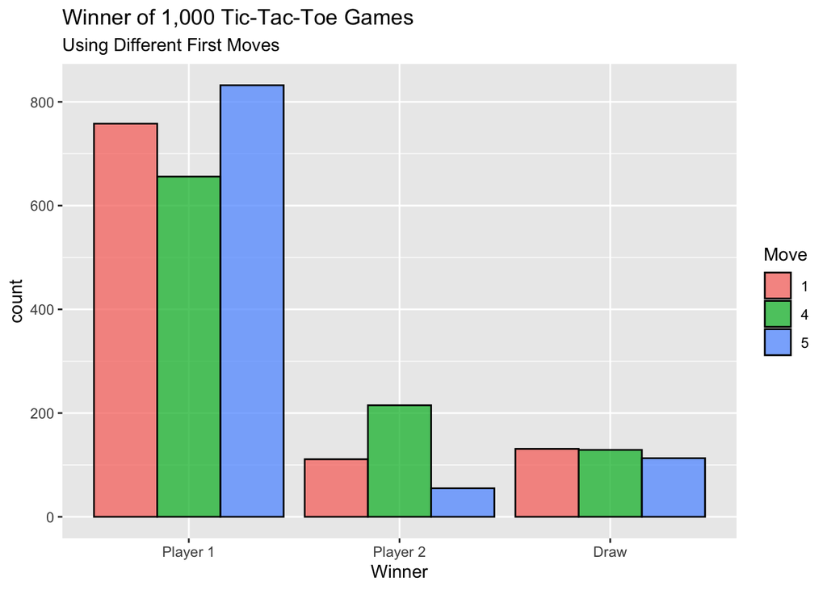

```r
df1$Move <- as.factor(df1$Move)
df1$Winner <- factor(df1$Winner, levels = c(1, -1, 0),
                    labels = c('Player 1', 'Player 2', 'Draw'))

ggplot(df1, aes(Winner)) +
  geom_bar(aes(fill = Move), position = 'dodge', color = 'black',
           alpha = 0.75) +
  ggtitle('Winner of 1,000 Tic-Tac-Toe Games',
          subtitle = 'Using Different First Moves')
```

```r
results <- data.frame(matrix(ncol = 3, nrow = 0))
colnames(results) <- c('Winner', 'First Move', 'Probability')

for (i in c(1,4,5)){
  df_fmove <- df1 %>% filter(Move == i)
  p1 <- length(df_fmove$Winner[df_fmove$Winner == 'Player 1']) / n; p1
  p2 <- length(df_fmove$Winner[df_fmove$Winner == 'Player 2']) / n; p2
  draw <- length(df_fmove$Winner[df_fmove$Winner == 'Draw']) / n; draw

  res <- data.frame(Winner = c('Player 1', 'Player 2', 'Draw'),
                 'First Move' = i, Probability = c(p1,p2, draw))
  results <- rbind(results, res)
}

pt <- pivot_wider(results, id_cols = First.Move, names_from = Winner, values_from = Probability); pt
```

```
## # A tibble: 3 × 4
##   First.Move `Player 1` `Player 2`  Draw
##        <dbl>      <dbl>      <dbl> <dbl>
## 1          1      0.758      0.111 0.131
## 2          4      0.656      0.215 0.129
## 3          5      0.832      0.055 0.113
```

```r
knitr::kable(pt, align = 'cccc') %>% kable_styling(full_width = F)
```

| First.Move | Player 1 | Player 2 | Draw |
| --- | --- | --- | --- |
| 1 | 0.758 | 0.111 | 0.131 |
| 4 | 0.656 | 0.215 | 0.129 |
| 5 | 0.832 | 0.055 | 0.113 |

# For which second move does Player 2 have the highest probability of winning?

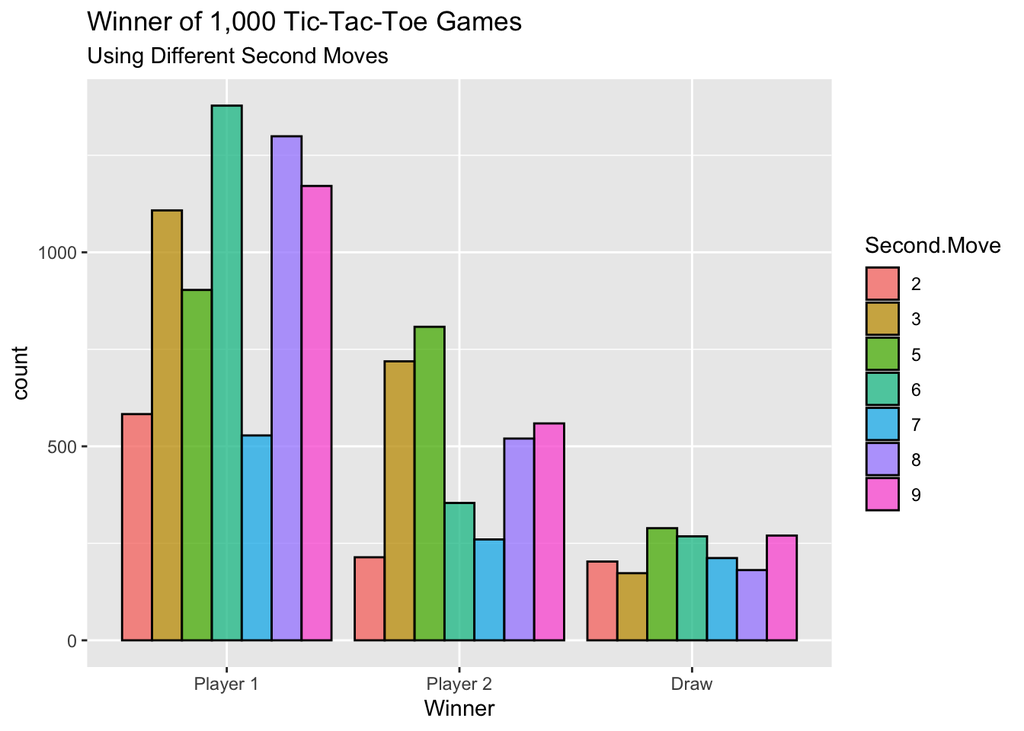

```r
board1 <- array(c(rep(NA,2), 1, rep(NA, 3), -1, rep(NA, 2)), dim = c(3,3))
board2 <- array(c(rep(NA,2), 1, rep(NA, 4), -1, NA), dim = c(3,3))
board3 <- array(c(rep(NA,2),-1,rep(NA,5), 1), dim = c(3,3))
board4 <- array(c(rep(NA,4),-1,rep(NA,3), 1), dim = c(3,3))
board5 <- array(c(rep(NA,5),-1,rep(NA,2), 1), dim = c(3,3))
board6 <- array(c(rep(NA,2),-1,rep(NA,4), 1, NA), dim = c(3,3))
board7 <- array(c(NA,-1,rep(NA,5), 1, NA), dim = c(3,3))
board8 <- array(c(rep(NA,5),1,NA, -1, NA), dim = c(3,3))
board9 <- array(c(rep(NA,4),-1, 1, rep(NA,3)), dim = c(3,3))
board10 <- array(c(rep(NA,5),1,rep(NA,2), -1), dim = c(3,3))
board11 <- array(c(rep(NA,4),1,rep(NA,3), -1), dim = c(3,3))
board12 <- array(c(rep(NA,4),1, -1, rep(NA, 3)), dim = c(3,3))

df1 <- data.frame(matrix(ncol = 3, nrow = 0))
colnames(df1) <- c('Winner', 'First Move', 'Second Move')

df1 <- randomSimulation(n, 3, board1, df = df1, seed = 0, 'Second Move')
df1 <- randomSimulation(n, 3, board2, df = df1, seed = 1, 'Second Move')
df1 <- randomSimulation(n, 3, board3, df = df1, seed = 2, 'Second Move')
df1 <- randomSimulation(n, 3, board4, df = df1, seed = 3, 'Second Move')
df1 <- randomSimulation(n, 3, board5, df = df1, seed = 4, 'Second Move')
df1 <- randomSimulation(n, 3, board6, df = df1, seed = 5, 'Second Move')
df1 <- randomSimulation(n, 3, board7, df = df1, seed = 6, 'Second Move')
df1 <- randomSimulation(n, 3, board8, df = df1, seed = 7, 'Second Move')
df1 <- randomSimulation(n, 3, board9, df = df1, seed = 8, 'Second Move')
df1 <- randomSimulation(n, 3, board10, df = df1, seed = 9, 'Second Move')
df1 <- randomSimulation(n, 3, board11, df = df1, seed = 10, 'Second Move')
df1 <- randomSimulation(n, 3, board12, df = df1, seed = 11, 'Second Move')

df1$First.Move <- as.factor(df1$First.Move)
df1$Second.Move <- as.factor(df1$Second.Move)
df1$Winner <- factor(df1$Winner, levels = c(1, -1, 0),
                    labels = c('Player 1', 'Player 2', 'Draw'))

ggplot(df1, aes(Winner)) +
  geom_bar(aes(fill = Second.Move), position = 'dodge', color = 'black',
           alpha = 0.75) +
  ggtitle('Winner of 1,000 Tic-Tac-Toe Games',
          subtitle = 'Using Different Second Moves')
```

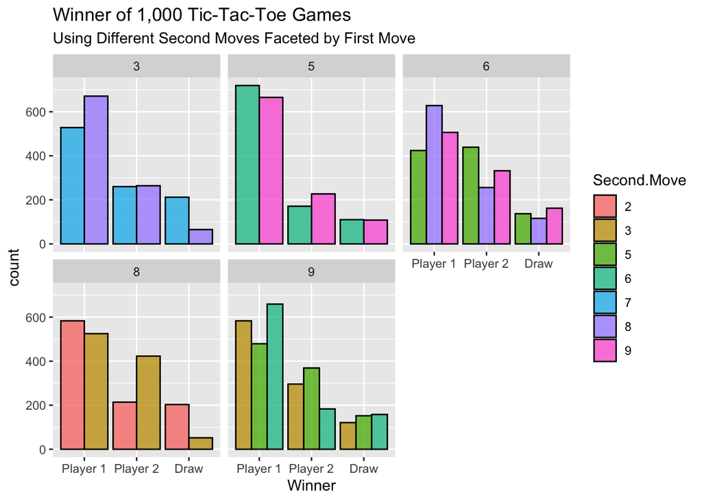

```r
ggplot(df1, aes(Winner)) +
  geom_bar(aes(fill = Second.Move), position = 'dodge', color = 'black',
           alpha = 0.75) + facet_wrap(~First.Move) +
  ggtitle('Winner of 1,000 Tic-Tac-Toe Games',
          subtitle = 'Using Different Second Moves Faceted by First Move')
```

```r
results <- data.frame(matrix(ncol = 4, nrow = 0))
colnames(results) <- c('Winner', 'Second Move', 'Probability')

for (i in 1:9){
  df_fmove <- df1 %>% filter(First.Move==i)
  print(dim(df_fmove))
  for (j in 1:9){
  df_smove <- df_fmove %>% filter(Second.Move == j)
  p1 <- length(df_smove$Winner[df_smove$Winner == 'Player 1']) / dim(df_smove)[1]; p1
  p2 <- length(df_smove$Winner[df_smove$Winner == 'Player 2']) / dim(df_smove)[1]; p2
  draw <- length(df_smove$Winner[df_smove$Winner == 'Draw']) / dim(df_smove)[1]; draw

  res <- data.frame(Winner = c('Player 1', 'Player 2', 'Draw'), 'First Move' = i,
                 'Second Move' = j, Probability = c(p1,p2, draw))
  results <- rbind(results, res)
  }
}
```

```
## [1] 0 3
## [1] 0 3
## [1] 2000    3
## [1] 0 3
## [1] 2000    3
## [1] 3000    3
## [1] 0 3
## [1] 2000    3
## [1] 3000    3
```

```r
pt <- pivot_wider(results, id_cols = c(First.Move,Second.Move), names_from = Winner, values_from = Probability)
pt <- na.omit(pt); pt
```

```
## # A tibble: 12 × 5
##    First.Move Second.Move `Player 1` `Player 2`  Draw
##         <int>       <int>      <dbl>      <dbl> <dbl>
##  1          3           7      0.528      0.26  0.212
##  2          3           8      0.671      0.264 0.065
##  3          5           6      0.719      0.171 0.11
##  4          5           9      0.665      0.227 0.108
##  5          6           5      0.424      0.439 0.137
##  6          6           8      0.628      0.256 0.116
##  7          6           9      0.506      0.332 0.162
##  8          8           2      0.583      0.214 0.203
##  9          8           3      0.525      0.423 0.052
## 10          9           3      0.583      0.296 0.121
## 11          9           5      0.479      0.369 0.152
## 12          9           6      0.659      0.183 0.158
```

```r
knitr::kable(pt, align = 'cccc') %>% kable_styling(full_width = F)
```

| First.Move | Second.Move | Player 1 | Player 2 | Draw |
| --- | --- | --- | --- | --- |
| 3 | 7 | 0.528 | 0.260 | 0.212 |
| 3 | 8 | 0.671 | 0.264 | 0.065 |
| 5 | 6 | 0.719 | 0.171 | 0.110 |
| 5 | 9 | 0.665 | 0.227 | 0.108 |
| 6 | 5 | 0.424 | 0.439 | 0.137 |
| 6 | 8 | 0.628 | 0.256 | 0.116 |
| 6 | 9 | 0.506 | 0.332 | 0.162 |
| 8 | 2 | 0.583 | 0.214 | 0.203 |
| 8 | 3 | 0.525 | 0.423 | 0.052 |
| 9 | 3 | 0.583 | 0.296 | 0.121 |
| 9 | 5 | 0.479 | 0.369 | 0.152 |
| 9 | 6 | 0.659 | 0.183 | 0.158 |

# Notes

- We can check if 3 in a row by summing three entries and checking if they are 0 mod 3.
- Right now Player1 is coded as 1, Player2 is coded as -1, and a draw is 0. And I am using winner as an indicator if the game is finished. If not, then winner is NULL.